# Xtern Class of 2021_Data Science Assessment

```r
install.packages("tidyverse")
install.packages("dplyr")
```

```
Error in install.packages : Updating loaded packages
```

```r
library(dplyr)
library(tidyverse)
library(readr)
```

```r
#Main database having 2019 observations
FoodieX <- read_csv("/Users/winnie/desktop/Class_2021-XTern-DS.csv")
str(FoodieX)
```

```
tibble [2,019 × 10] (S3: spec_tbl_df/tbl_df/tbl/data.frame)
 $ Restaurant   : chr [1:2019] "ID_6321" "ID_2882" "ID_1595" "ID_5929" ...
 $ Latitude     : num [1:2019] 39.3 39.8 39.3 39 39.9 ...
 $ Longitude    : num [1:2019] -85.8 -85.7 -85.1 -85.3 -85.5 ...
 $ Cuisines     : chr [1:2019] "Fast Food, Rolls, Burger, Salad, Wraps" "Ice Cream, Desserts" "Italian, Street Food, Fast Food" "Mughlai, North Indian, Chinese" ...
 $ Average_Cost : chr [1:2019] "$20.00" "$10.00" "$15.00" "$25.00" ...
 $ Minimum_Order: chr [1:2019] "$50.00" "$50.00" "$50.00" "$99.00" ...
 $ Rating       : chr [1:2019] "3.5" "3.5" "3.6" "3.7" ...
 $ Votes        : chr [1:2019] "12.0" "11.0" "99.0" "176.0" ...
 $ Reviews      : chr [1:2019] "4.0" "4.0" "30.0" "95.0" ...
 $ Cook_Time    : chr [1:2019] "30 minutes" "30 minutes" "65 minutes" "30 minutes" ...
 - attr(*, "spec")=
  .. cols(
  ..   Restaurant = col_character(),
  ..   Latitude = col_double(),
  ..   Longitude = col_double(),
  ..   Cuisines = col_character(),
  ..   Average_Cost = col_character(),
  ..   Minimum_Order = col_character(),
  ..   Rating = col_character(),
  ..   Votes = col_character(),
  ..   Reviews = col_character(),
  ..   Cook_Time = col_character()
  .. )
```

```r
summary(FoodieX)
```

```
  Restaurant           Latitude       Longitude        Cuisines
 Length:2019        Min.   :39.00   Min.   :-86.00   Length:2019
 Class :character   1st Qu.:39.26   1st Qu.:-85.75   Class :character
 Mode  :character   Median :39.49   Median :-85.51   Mode  :character
                    Mean   :39.50   Mean   :-85.50
                    3rd Qu.:39.74   3rd Qu.:-85.25
                    Max.   :40.00   Max.   :-85.00
 Average_Cost       Minimum_Order         Rating             Votes
 Length:2019        Length:2019        Length:2019        Length:2019
 Class :character   Class :character   Class :character   Class :character
 Mode  :character   Mode  :character   Mode  :character   Mode  :character



   Reviews           Cook_Time
 Length:2019        Length:2019
 Class :character   Class :character
 Mode  :character   Mode  :character
```

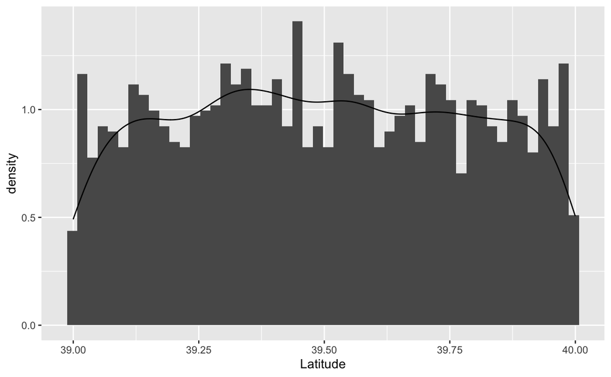

```r
#Latitude
ggplot(FoodieX, aes(x=Latitude)) + geom_histogram(bins =50,aes(y=..density..)) +geom_density()
```

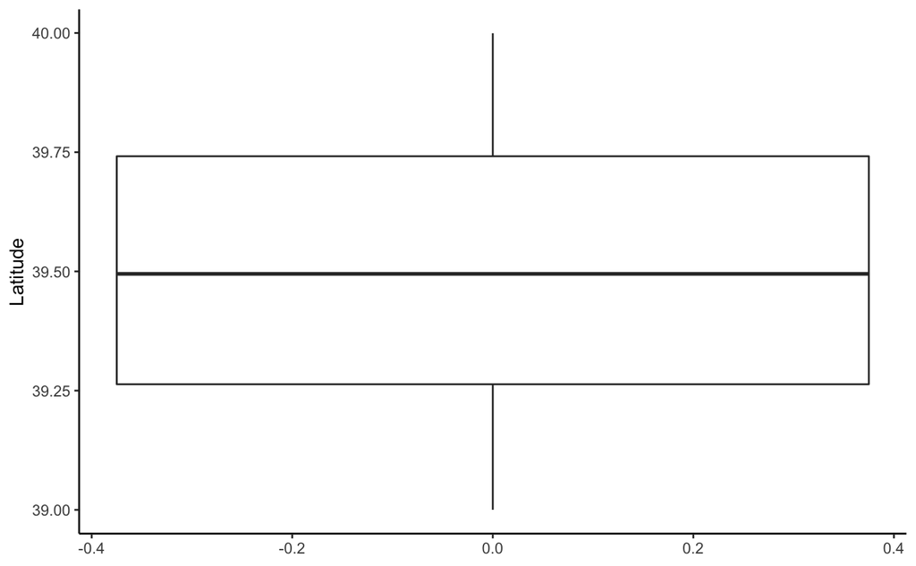

```r
ggplot(FoodieX, aes(x=Latitude)) + geom_boxplot() + coord_flip() + theme_classic()
```

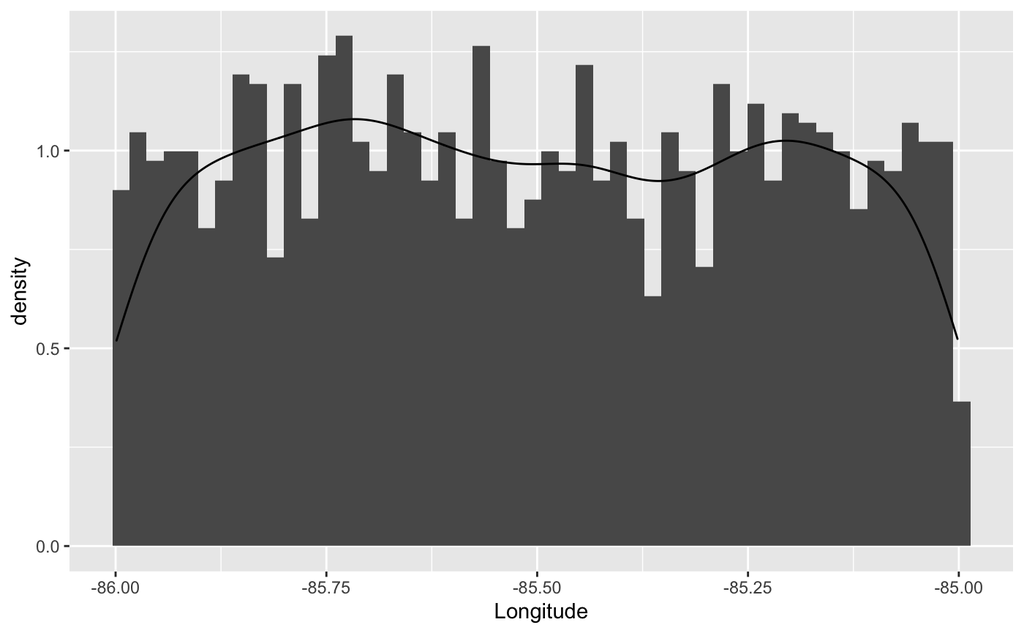

```r
#Longtitude
ggplot(FoodieX, aes(x=Longitude)) + geom_histogram(bins =50,aes(y=..density..)) +geom_density()
```

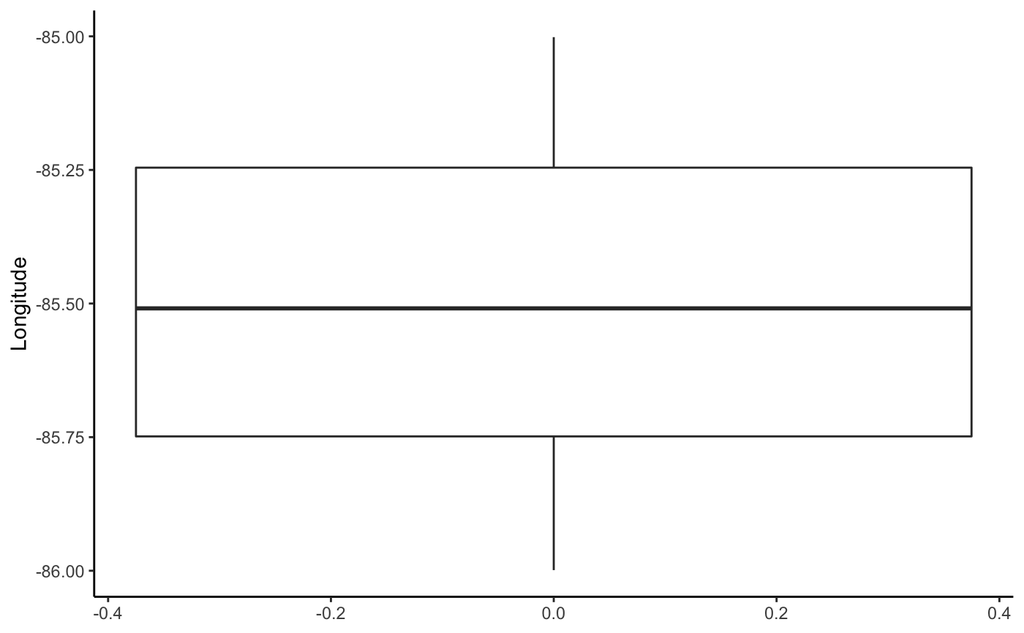

```r
ggplot(FoodieX, aes(x=Longitude)) + geom_boxplot() + coord_flip() + theme_classic()
```

```r
#Interactive grpah between numeric vcariables
GPS <- FoodieX[,c('Latitude', 'Longitude')]
cor(GPS)
```

```
             Latitude   Longitude
Latitude  1.000000000 0.002166235
Longitude 0.002166235 1.000000000
```

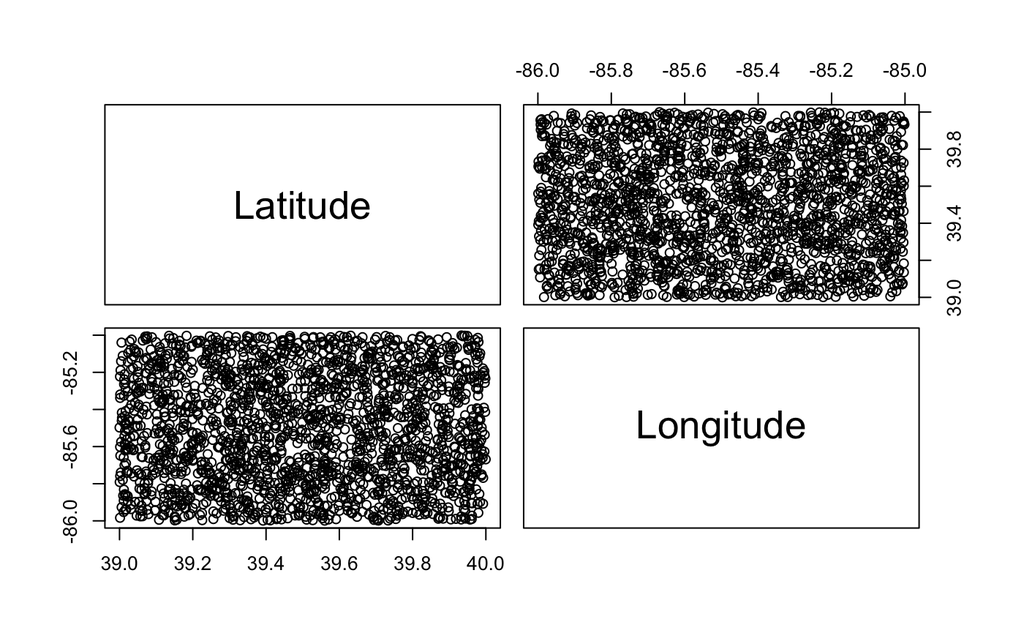

```r
pairs(GPS[,c(1:2)])
```

Convert Data Convert all character columns into numeric columns except for Restaurant (ID) & Cuisines.However, there are lots of cell with NA data which leads to the next action: filter and get rid of NA data row (this non-NA dataset is used for Model 1 below)

```r
FoodieX$Rating <- as.numeric(as.character(FoodieX$Rating))
```

```
NAs introduced by coercion
```

```r
FoodieX$Votes <- as.numeric(as.character(FoodieX$Votes))
```

```
NAs introduced by coercion
```

```r
FoodieX$Reviews <- as.numeric(as.character(FoodieX$Reviews))
```

```
NAs introduced by coercion
```

```r
trending <- FoodieX[,c('Cuisines','Rating', 'Votes', 'Reviews')]
na_vec <- which(!complete.cases(trending))
#Create a dataset without NA data
model1_data <- trending[-na_vec,]
```

```r
model1 <- lm(Rating ~ Votes+Reviews, data = model1_data)
summary(model1)
```

```
Call:
lm(formula = Rating ~ Votes + Reviews, data = model1_data)

Residuals:
     Min       1Q   Median       3Q      Max
-1.74742 -0.24185  0.03402  0.24947  1.15725

Coefficients:
              Estimate Std. Error t value Pr(>|t|)
(Intercept)  3.538e+00  1.058e-02 334.483  < 2e-16 ***
Votes        3.224e-04  6.300e-05   5.118 3.47e-07 ***
Reviews     -1.532e-06  1.081e-04  -0.014    0.989
---
Signif. codes:  0 ‘***’ 0.001 ‘**’ 0.01 ‘*’ 0.05 ‘.’ 0.1 ‘ ’ 1

Residual standard error: 0.3777 on 1601 degrees of freedom
Multiple R-squared:  0.189, Adjusted R-squared:  0.188
F-statistic: 186.5 on 2 and 1601 DF,  p-value: < 2.2e-16
```

```r
model1_2 <- lm(Rating ~ Reviews, data = model1_data)
summary(model1_2)
```

```
Call:
lm(formula = Rating ~ Reviews, data = model1_data)

Residuals:
     Min       1Q   Median       3Q      Max
-2.31334 -0.25554  0.03648  0.24406  1.12159

Coefficients:
             Estimate Std. Error t value Pr(>|t|)
(Intercept) 3.554e+00  1.019e-02  348.88   <2e-16 ***
Reviews     5.319e-04  2.878e-05   18.48   <2e-16 ***
---
Signif. codes:  0 ‘***’ 0.001 ‘**’ 0.01 ‘*’ 0.05 ‘.’ 0.1 ‘ ’ 1

Residual standard error: 0.3806 on 1602 degrees of freedom
Multiple R-squared:  0.1757,    Adjusted R-squared:  0.1752
F-statistic: 341.5 on 1 and 1602 DF,  p-value: < 2.2e-16
```

```r
model1_3 <- lm(Rating ~ Votes, data = model1_data)
summary(model1_3)
```

```
Call:
lm(formula = Rating ~ Votes, data = model1_data)

Residuals:
    Min      1Q  Median      3Q     Max
-1.7496 -0.2419  0.0340  0.2494  1.1571

Coefficients:
             Estimate Std. Error t value Pr(>|t|)
(Intercept) 3.538e+00  1.037e-02  341.03   <2e-16 ***
Votes       3.216e-04  1.664e-05   19.32   <2e-16 ***
---
Signif. codes:  0 ‘***’ 0.001 ‘**’ 0.01 ‘*’ 0.05 ‘.’ 0.1 ‘ ’ 1

Residual standard error: 0.3776 on 1602 degrees of freedom
Multiple R-squared:  0.189, Adjusted R-squared:  0.1885
F-statistic: 373.3 on 1 and 1602 DF,  p-value: < 2.2e-16
```

Conclusion 3: Best Rating Restaurants (4.0 rating) + There are a total 112 restaurants which have a maximum rating of 4.0. Out of 2019 restaurants in the original dataset, this number accounts for 5%. + Among 112 restaurants with 4.0 rating, restaurants serving Indian food account for 35 % (39 restaurants), restaurants serving Chinese food account for 25% (28 restaurants).

Conclusion 4: The popularity of Indian & Chinese Cuisine in Indianapolis All in all, we can say, Indian and Chinese cuisine are the two main parts of Indianapolis restaurant type, accounting for 16.8% and 12.5% of restaurants in Indy (in total). 10% out of each cuisine restaurant serves high quality food and has good customer service as they have 4.0 (maximum) rating. Conclusion 4.1: Indian Cuisine + There are 339 restaurants serving Indian food in Indianapolis (out of 2019 restaurants). However, we only have 39 high quality (rate 4.0) restaurants accounting for only 11.5% Conclusion 4.2: Chinese Cuisine + There are 252 restaurants serving Chinese food in Indianapolis (out of 2019 restaurants). However, we only have 28 high quality (rate 4.0) restaurants accounting for only 11.1%

```r
#Total number of high rate (4.0) restaurants in Indianapolis
high_rate <- filter(model1_data,Rating==4.0)
#Total number of Indian restaurants which has 4.0 rating in Indianapolis
Indian_high_quality <- high_rate %>% select(Cuisines, Votes) %>% filter(str_detect(Cuisines, "Indian")) %>%
  count(Cuisines)
#Total number of Indian restaurants in Indianapolis
Indian_total <- FoodieX %>% select(Cuisines) %>% filter(str_detect(Cuisines, "Indian")) %>%count(Cuisines)
#Total number of Chinese restaurants in Indianapolis
Chinese_total <- FoodieX %>% select(Cuisines) %>% filter(str_detect(Cuisines, "Chinese")) %>%count(Cuisines)
#Total number of Chinese restaurants which has 4.0 rating in Indianapolis
Chinese_high_quality <- high_rate %>% select(Cuisines, Votes) %>% filter(str_detect(Cuisines, "Chinese")) %>% count(Cuisines)
```